# DATS - 6101 - Mass Shootings in the United States

Julius Frank, Natasha Vij, Meg Elliott Fitzgerald

## Section I

For our group project, we chose to use a dataset on mass shooters in the United States in recent years. The dataset includes demographic data about the shooters and victims, as well as several datapoints containing incident details of each shooting. As we considered potential research questions, we naturally gravitated towards the shooter's demographic data in hopes of identifying a unique profile of contemporary mass shooters in the United States. Should we be able to develop such a profile, it could be used in the development of programs or mitigations that may potentially prevent or lessen the occurence of these tragic events in the future.

The dataset contained many dimensions pertaining to the shooter, so the task quickly became one of determining what research question we could craft that would meet all of the criteria of a SMART data science question. The idea of determining if there are differences between the demographic profile of a mass shooter and that of the average American is salient albeit quite general. We needed to articulate more clearly which demographic datapoints we would use in our analysis in order to meet the goal of *specificity*. Identifying the dimensions most ripe for analysis involved some Exploratory Data Analysis (detailed below) and resulted in the narrowing of our mass shooter profile to include Age, Race and Sex. After finding other reliable data sources that could give us information about the average American, we determined that finding this answer would be both *measurable* and *achievable*. The topic of mass shooting prevention in the United States is already highly *relevant*, as these incidents have increased dramatically over the last several decades. Lastly, the tests we planned to run would allow us to complete a deep analysis within the allotted *timeframe*.

As a result of this exercise we could go forward with the analysis confidently, in search of an answer to the question: **"Is the contemporary mass shooter in America similar to the average American demographically regarding age, race, and sex?"**

## Section II

The Stanford Mass Shootings in America (MSA) is a dataset released under the Creative Commons Attribution 4.0 international license by the Stanford Geospatial Center. The definition of mass shooting that was used for this database is “3 or more shooting victims (not necessarily fatalities), not including the shooter. The shooting must not be identifiably gang, drug, or organized crime related”. This data collection process began in 2012 after the deadly mass shooting in Sandy Hook, CT. The Stanford Geospatial Center set out to create a repository for as many mass shooting events as could be collected via online media. The Stanford MSA database aims to aggregate data by looking at online media sources. The goal of this database is to make data more accessible for the public to help provide further research on gun violence within the United States. The Stanford Geospatial Center acknowledges that this dataset is not a complete list of every single incident of mass shooting that have occurred from 1966-2016; however, it considers itself to be a high-quality dataset. This dataset includes source URLs for user confirmation and validation, which allowed our group to confirm the accuracy of the data that was provided.

The Stanford MSA dataset that was created by the Stanford Geospatial Center is only limited to online media resources. According to the Stanford Geospatial Center, they started this database by initially investigating mass shootings by looking at existing online reports that went back to 1966. However, due to a lack of available media records, the organization found it challenging to cross reference their information. Records that the organization has made public can now be cross checked for accuracy. Stanford Geospatial Center currently has a standard of corroborating their information against at least 3 different sources; however, they have utilized as many as 6-7 sources as well. These sources have been listed in the actual database for users to access for evidence. The organization also notes that there can be up to a 4-week lag between an event occurring and its details being made available on the database. This is due to the organization’s high standards of corroborating details in order to provide highly accurate data.

Stanford Geospatial Center notes that their reporting is limited because online media reporting was incredibly limited in the early stages of their reporting. Web-based news and information reporting made it much easier for the organization to collect data into one concise database. They caution that researchers using this database need to be aware that there is a reporting bias in the database because of unavoidable technological issues. While it might seem like there was a large spike of events in recent years, this spike is not indicative of events that have occurred.

```python
import numpy as np
import pandas as pd
import seaborn as sns; sns.set()
import matplotlib.pyplot as plt
from statsmodels.stats.weightstats import ztest
from scipy.stats import chisquare
sns.set_style("whitegrid")
import warnings
warnings.filterwarnings("ignore", category=FutureWarning)

full_sample_df = pd.read_excel('DATS101 Group Project Dataset 2.xlsx',sheet_name='expanded_raw_data')
sample_df = pd.read_excel('DATS101 Group Project Dataset 2.xlsx',sheet_name='2010_known_data')
pop_df = pd.read_excel('mean age.xlsx',sheet_name='Sheet1')
pop_df.drop(pop_df.tail(1).index,inplace=True)

weapon_attributes = ['Type of Gun - Detailed', 'Type of Gun - General', 'Number of Shotguns', 'Number of Rifles',
                     'Number of Handguns', 'Total Number of Guns', 'Number of Automatic Guns',
                     'Number of Semi-Automatic Guns']
incident_attributes = ['Title', 'Location', 'Description', 'Date', 'Day of Week', 'School Related',
                       'Place Type', 'Relationship to Incident Location', 'Possible Motive - Detailed',
                       'Possible Motive - General']
shooter_attributes = ['Shooter Name', 'Shooter Age(s)', 'Average Shooter Age', 'Shooter Sex', 'Shooter Race',
                      'History of Mental Illness - General', 'Military Experience', 'Class']
```

### Mass Shootings Per Year (showing spike of events in recent years)

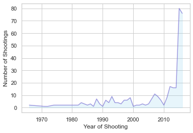

```python
plt.fill_between(list(set(full_sample_df['Year'])), list(full_sample_df.groupby(['Year'])['Year'].count()),
         color = 'skyblue', alpha = 0.2)
plt.plot(list(set(full_sample_df['Year'])), list(full_sample_df.groupby(['Year'])['Year'].count()),
         color = 'Slateblue', alpha = 0.6)
plt.xlabel("Year of Shooting")
plt.ylabel("Number of Shootings")
plt.show()
```

Due to the data collection process of the Stanford MSA and since we chose to use comparison data from the 2010 census (more information on that dataset below), we decided to limit the dataset to only those shootings occurring in or after 2010.

### Mass Shootings Per Year (2010-2016)

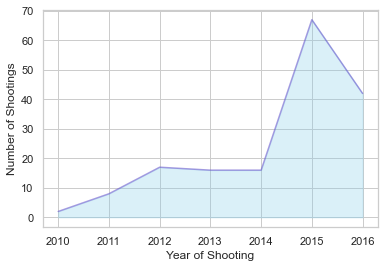

```python
plt.fill_between(sorted(list(set(sample_df['Year']))), list(sample_df.groupby(['Year'])['Year'].count()),
         color = 'skyblue', alpha = 0.3)
plt.plot(sorted(list(set(sample_df['Year']))), list(sample_df.groupby(['Year'])['Year'].count()),
         color = 'Slateblue', alpha = 0.6)
plt.xlabel("Year of Shooting")
plt.ylabel("Number of Shootings")
plt.show()
```

The rate of actual mass shootings is most likely going to be different compared to what this database depicts. The goal of this database is to collect quality data regarding mass shootings, rather than organizing a full collection of data on every single mass shooting event that has happening between 1966-2016. Further verification would be required to examine trends in mass shootings over a series of time. This ultimately becomes a limitation of this dataset is that the Stanford Geospatial Center acknowledges that this is not an exhaustive list of all mass shootings that have occurred from 1966-2016. With respect to our analysis and testing, some of the tests conducted for this project could be slightly skewed with different datapoints.

### Dataset Features

This dataset had 168 incidents of mass shootings already available for use. There were many different variables that were included in this dataset, including both a short and detailed explanation of certain variables.

#### Examples of variables regarding weapons used:

```python
sample_df[weapon_attributes].head(3)
```

|  | Type of Gun - Detailed | Type of Gun - General | Number of Shotguns | Number of Rifles | Number of Handguns | Total Number of Guns | Number of Automatic Guns | Number of Semi-Automatic Guns |
| --- | --- | --- | --- | --- | --- | --- | --- | --- |
| 0 | 9mm pistol | Handgun | 0 | 0 | 1 | 1 | 0 | 1 |
| 1 | Two Ruger SR9 9mm semi-automatic pistols | Handgun | 0 | 0 | 2 | 2 | 0 | 2 |
| 2 | 9mm Glock 19 semi-automatic pistol | Handgun | 0 | 0 | 1 | 1 | 0 | 1 |

#### Examples of variables regarding details of the shooting:

```python
sample_df[incident_attributes].head(3)
```

|  | Title | Location | Description | Date | Day of Week | School Related | Place Type | Relationship to Incident Location | Possible Motive - Detailed | Possible Motive - General |
| --- | --- | --- | --- | --- | --- | --- | --- | --- | --- | --- |
| 0 | University of Alabama in Huntsville | Huntsville, Alabama | On February 12, 2010, a 44-year old professor ... | 2010-02-12 | Friday | Yes | College/University/Adult education | Place of business/employment | The shooter had been denied tenure and expecte... | Terminated/Denied/Reprimanded |
| 1 | Hartford Beer Distributors | Manchester, Connecticut | On August 3, 2010, a 34-year old man was calle... | 2010-08-03 | Tuesday | No | Company/Factory/Office | Place of business/employment | The shooter was laid off his job. In a phone c... | Terminated/Denied/Reprimanded |
| 2 | Tucson, Arizona | Tucson, Arizona | On January 8, 2011, a 22-year old went to a pa... | 2011-01-08 | Saturday | No | Retail/Wholesale/Services facility | None | The shooter had a profound dislike for the con... | Multiple motives |

#### Examples of variables regarding the shooter:

```python
sample_df[shooter_attributes].head(3)
```

|  | Shooter Name | Shooter Age(s) | Average Shooter Age | Shooter Sex | Shooter Race | History of Mental Illness - General | Military Experience | Class |
| --- | --- | --- | --- | --- | --- | --- | --- | --- |
| 0 | Dr. Amy Bishop | 44 | 44 | Female | White American or European American | No | Unknown | MS |
| 1 | Omar Shariff Thornton | 34 | 34 | Male | Black American or African American | Unknown | Unknown | MS |
| 2 | Jared Lee Loughner | 22 | 22 | Male | White American or European American | Yes | Unknown | MS |

Some of the key variables we were interested in using for our exploratory data analysis included age, race, sex, location, mental health status, and military experience. Most of these data points had already been isolated; however, shootings with multiple perpetrators had their age averaged out. However, since we wanted to analyze the data on shooters and not shooting incidents, we needed compile our data into profiles about individual shooters. This was done manually, as the number of shooting with multiple shooters was relatively small.

During our exploratory data analysis, we started researching census data. In this stage, we realized that we could compare mass shooter’s age, race, and sex easily. This allowed us to start formulating our SMART question: “Is the average mass shooter in America similar to the average American demographically by age, race, sex, location, mental health status, and military experience?”.

### Dataset Limitations

During the beginning stages of our exploratory data analysis, we wanted to compare age, race, sex, location, mental health status, and military experience of mass shooters to the average American. However, while conducting our research, we found it challenging to obtain meaningful data for both the mental health status and military experience. This challenge was due to the high level of unknown variables within both variables. Furthermore, we failed to obtain mental health data that corresponded to the proper age range. The Substance Abuse and Menal Health Services Administration collects data on mental health diagnoses; however, they only record data from adults 18 and over. Our dataset included perpetrators under the age of 18; therefore, we decided that any kind of testing for this data would not have been fair or accurate. Additionally, we found it difficult to test our state population data as well because state population data could potentially be problematic due to the varying demographics of each state.

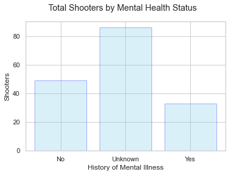

```python
plt.bar(sorted(list(set(sample_df['History of Mental Illness - General']))),
        list(sample_df.groupby(['History of Mental Illness - General'])['History of Mental Illness - General'].count())
        , color='skyblue', edgecolor = 'blue', alpha = 0.3)
plt.xlabel("History of Mental Illness")
plt.ylabel("Shooters")
plt.suptitle("Total Shooters by Mental Health Status")
plt.show()
```

Out of 168 shooters, mental health status was unknown for 86 individuals.

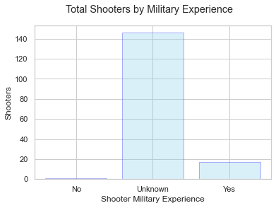

```python
plt.bar(sorted([x for x in list(set(sample_df['Military Experience'])) if str(x) != 'nan']),
        list(sample_df.groupby(['Military Experience'])['Military Experience'].count())
        , color='skyblue', edgecolor = 'blue', alpha = 0.3)
plt.xlabel("Shooter Military Experience")
plt.ylabel("Shooters")
plt.suptitle('Total Shooters by Military Experience')
plt.show()
```

Only 17 shooters had military experience, but this information was absent for 146 of the shooters. Another 4 shooters had null values.

We decided to change the scope of our question when we realized that we were not going to be able to create a meaningful analysis out of the unknown variable challenge we were presented within this dataset. We ultimately decided to eliminate the three problematic variables from our testing and finalize our SMART question: “Is the average mass shooter in America similar to the average American demographically by age, race, and sex?”

### Exploratory Data Analysis: Age

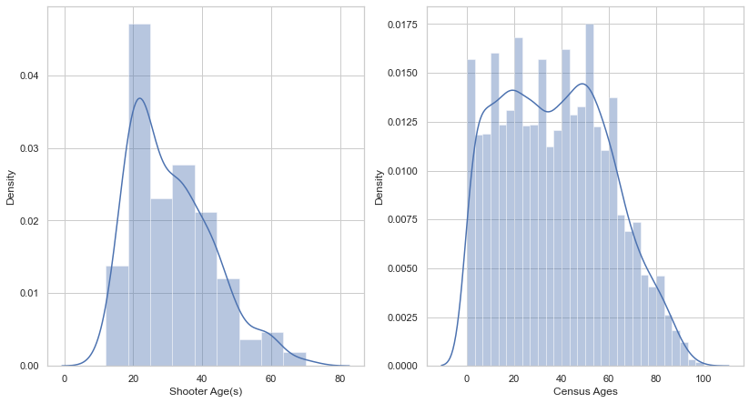

```python
pop_df
pop_recon = []
counter = 0
for i in pop_df['Proportion of population']:
    for x in range(round(i*10000)):
        pop_recon.append(counter)
    counter += 1
dims = (13.7, 7.27)
fig, (ax1, ax2) = plt.subplots(ncols = 2, figsize = dims)
sns.distplot(sample_df['Shooter Age(s)'], ax = ax1)
sns.distplot(pop_recon, axlabel = 'Census Ages', ax=ax2)
plt.show()
```

```python
# filling in blank shooter age data
shooter_age_count_df = sample_df.groupby(by='Shooter Age(s)').count().iloc[:,1]
shooter_age_dict = {}
for i in range(12,71):
    try:
        shooter_age_dict[i] = shooter_age_count_df[i]
    except:
        shooter_age_dict[i] = 0
full_shooter_age_count_df = pd.DataFrame(shooter_age_dict,index=['Shooter Age']).T
```

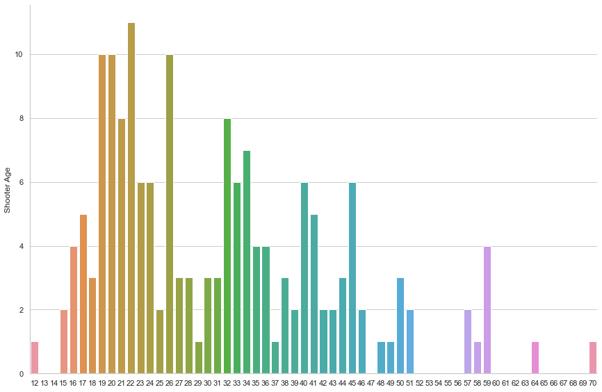

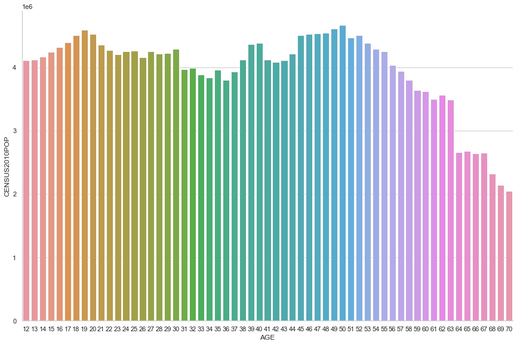

```python
sns.catplot(x=full_shooter_age_count_df.index,y='Shooter Age', kind = 'bar', data=full_shooter_age_count_df, height = 8, aspect = 1.5)
sns.catplot(x='AGE', y='CENSUS2010POP', kind = 'bar', data=pop_df[12:71], height = 8, aspect = 1.5)
plt.show()
```

```python
# from https://www.census.gov/prod/cen2010/briefs/c2010br-02.pdf
census_race = {
    'Asian American': 14674252,
    'Black American or African American':  38929319,
    'Native American or Alaska Native':  2932248,
    'Some other race': 19647381,
    'Two or more races':    9009073 ,
    'White American or European American':  223553265
}
compare_race = {'Shooter': list(sample_df.groupby('Shooter Race').count().iloc[:,0]), 'Overall': list(census_race.values())}
compare_race_df = pd.DataFrame(compare_race,index=list(census_race.keys()))
pop_race_list = list(census_race.keys())
pop_race_counts = list(census_race.values())
shooter_race_counts = list(sample_df.groupby('Shooter Race').count().iloc[:,0])
```

### Exploratory Data Analysis: Race

There were dramatic differences in race stratification between the two datasets, with Black Americans being overrepresented in the shooter dataset as compared to the census data. This overrepresentation seemed to leech only from the White American category, as all other denominations were roughly unchanged between the two datasets.

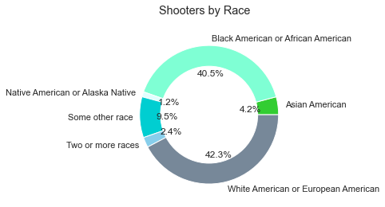

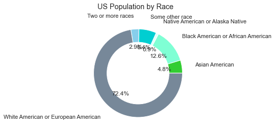

|  | Shooter | Overall |
| --- | --- | --- |
| Asian American | 7 | 14674252 |
| Black American or African American | 68 | 38929319 |
| Native American or Alaska Native | 2 | 2932248 |
| Some other race | 16 | 19647381 |
| Two or more races | 4 | 9009073 |
| White American or European American | 71 | 223553265 |

```python
shades = ['limegreen', 'aquamarine', 'lightcyan', 'darkturquoise', 'skyblue', 'lightslategray']
my_circle = plt.Circle( (0,0), 0.7, color = 'white')
plt.pie(shooter_race_counts, labels = pop_race_list, labeldistance = 1.1,
       colors = shades,
       autopct = "%.1f%%")
p = plt.gcf()
p.gca().add_artist(my_circle)
plt.suptitle('Shooters by Race')
plt.show()

my_circle = plt.Circle( (0,0), 0.7, color = 'white')
plt.pie(pop_race_counts, labels = pop_race_list, labeldistance = 1.3,
       colors = shades,
       autopct = "%.1f%%")
p = plt.gcf()
p.gca().add_artist(my_circle)
plt.suptitle('US Population by Race')
plt.show()
compare_race_df
```

Black shooters skewed younger both within the group and compared to White shooters.

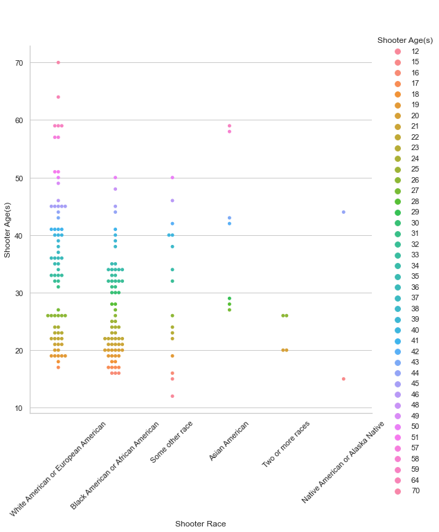

```python
catplot = sns.catplot(y='Shooter Age(s)', x = 'Shooter Race', hue = 'Shooter Age(s)', kind = 'swarm', data=sample_df, height = 8)
catplot.set_xticklabels(rotation=45)
plt.show()
```

### Exploratory Data Analysis: Sex

The shooter dataset also skewed much more male than the US population, with women and girls representing only 3% of shooters, compared to roughly half of all US citizens.

```python
# from https://www.census.gov/prod/cen2010/briefs/c2010br-03.pdf
census_sex = {
    'Female': 156964212,
    'Male': 151781326
}
compare_sex = {'Shooter': list(sample_df.groupby('Shooter Sex').count().iloc[:,0]), 'Overall': list(census_sex.values())}
compare_sex_df = pd.DataFrame(compare_sex,index=list(census_sex.keys()))
```

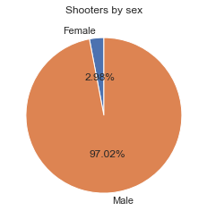

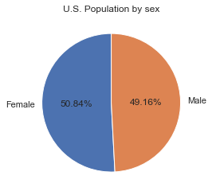

```python
p = compare_sex_df.plot.pie(y='Shooter',legend=None,title='Shooters by sex',autopct="%.2f%%",
startangle=90,
pctdistance=0.5,
labeldistance=1.1)
p.set_ylabel(None)
q = compare_sex_df.plot.pie(y='Overall',legend=None,title='U.S. Population by sex',autopct="%.2f%%",
startangle=90,
pctdistance=0.5,
labeldistance=1.1)
q.set_ylabel(None)
plt.show()
```

## Section III

Once we completed our exploratory data analysis, we started thinking about various ways to test our data. Since our data was related to population data, we were already able to visualize the average mass shooter through age, race, and sex. However, it would not have been possible to sketch out a complete answer to our new SMART question until we started testing our data because we did not know how the overall population skewed. Therefore, we knew that we would need to test our data in order to find a meaningful answer to our SMART question.

Since sex and race are categorical variables, we concluded that a $\chi^2$ test would be most appropriate. We chose a $\chi^2$ test because categorical variables test if the distribution of specific characteristics is the similar between the general American public and the mass shooter population.

#### Testing Race Stratification

```python
print('𝜒2 Statistic:', chisquare(compare_race_df,axis=None)[0])
print('p-value:', chisquare(compare_race_df,axis=None)[1])
```

```
𝜒2 Statistic: 1719434814.6986284
p-value: 0.0
```

#### Testing Sex Stratification

```python
print('𝜒2 Statistic:', chisquare(compare_sex_df,axis=None)[0])
print('p-value:', chisquare(compare_sex_df,axis=None)[1])
```

```
𝜒2 Statistic: 308919043.26943034
p-value: 0.0
```

#### Testing Age Stratification

Testing the difference in age proved to be a little more of a challenge. Traditionally the census only keeps track of median age. A $Z$-test cannot properly and fairly test a sample mean against a population median. However, by using the definition of the expected value and looking at the reporting of the headcount of Americans from ages 1 to 100, we were able to reconstruct the mean age from census data. The mean age of the shooter dataset is roughly 31 years old.

```python
print('Mass Shooter Mean Age: ', sample_df.loc[:,'Shooter Age(s)'].mean())
```

```
Mass Shooter Mean Age:  31.06547619047619
```

```python
print('𝑍-Statistic:', ztest(x1=sample_df.loc[:,'Shooter Age(s)'],value=pop_df.loc[:,'Average component'].sum())[0])
print('p-value:', ztest(x1=sample_df.loc[:,'Shooter Age(s)'],value=pop_df.loc[:,'Average component'].sum())[1])
```

```
𝑍-Statistic: -6.864955446942162
p-value: 6.651200800354528e-12
```

The $Z$-test allows us to confirm that we may reject our null hypothesis, which assumed that the average age of the mass shooter group was the same as that of the American population. Said differently, we can safely assert that the average age of a mass shooter in America is not the same as the average age of American citizens.

This information then allowed us to use the $Z$-test legitimately. Our model predicts that mass shooters are disproportionately younger than the average American. Additionally, mass shooters are more likely to be male and are typically either White or African American. Thus, any policy seeking to reduce the number of mass shooting incidents (like creating a stronger mental health intervention programs) these programs must be targeted towards young, White or African American men in order to see true change in incidents.

## Conclusions

Through the three tests we conducted, we were able to reject our null hypothesis and conclude that the average American is not similar to the mass shooter population in terms of age, race, and sex. However, it could have been beneficial to have more demographic information on the mass shooter. For example, if we were able to obtain information pertaining to the shooter’s political alignment, we could have been able to see whether there was a correlation between political affiliation and perpetrating mass shootings. Since political polarization can lead to mass shootings, it would be beneficial to see raw data on this variable. Examining information on shootings after 2016 would also be helpful since mass shootings did not stop after 2016. It would have beneficial to get a more comprehensive understanding of recent incidents of mass shootings within the United States. We also believe that it would have been interesting to examine economic class trends within this dataset in order to see how economic backgrounds played into mass shooters perpetrating events.

Given that we meet all the required pre-conditions for all the tests we used in this report, we are confident about our conclusions about the differences in demographics between mass shooters and the general American population. While our report is conclusive, the part of the population that it singles out for being more likely to commit mass shootings is still very large. In order to create a more meaningful analysis, it would be helpful in further reports to collect information such as economic class, political affiliation, criminal history, military affiliation, and mental health history to examine which individuals are most at-risk individuals and make intervention methods more effective.

## References:

"Mass Shootings in America.” library.standford.edu. https://library.stanford.edu/projects/mass-shootings-america (accessed Oct. 14, 2020). "Stanford Mass Shootings in America (MSA).” www.kaggle.com. https://www.kaggle.com/carlosparadis/stanford-msaselect=mass_shooting_events_stanford_msa_release_06142016.csv (accessed Oct. 14, 2020). "Overview of Race and Hispanic Origin: 2010.” www.census.gov. https://www.census.gov/prod/cen2010/briefs/c2010br-02.pdf (accessed Nov. 9, 2020). "Age and Sex Composition: 2010.” www.census.gov. https://www.census.gov/prod/cen2010/briefs/c2010br-03.pdf (accessed Nov. 9, 2020). "Results from the 2010 NSDUH: Mental Health Findings, SAMHSA, CBHSQ.” www.samhsa.gov. https://www.samhsa.gov/data/sites/default/files/2k10MH_Findings/2k10MH_Findings/2k10MHResults.htm (accessed Nov. 9, 2020).